# MA615 Hurricane Project

Fan Feng

2020/11/12

# Introduction

The purpose of this assignment is to show that we know the basics of using R to produce documents, presentations, and shiny apps. These are basic skills that every data scientists must have.

In this assignment, we use the mapping project you have just completed as a starting point. In addition, we have more county level data from FEMA and FEC so that we can produce maps with relevant features.

# Data Description

The Public Assistance Funded Projects Details dataset contains obligated (financial obligation to grantee) Public Assistance projects.

FEMA provides supplemental Federal disaster grant assistance for debris removal, emergency protective measures, and the repair, replacement, or restoration of disaster-damaged, publicly owned facilities and the facilities of certain Private Non-Profit (PNP) organizations through the PA Program. The PA Program also encourages protection of these damaged facilities from future events by providing assistance for hazard mitigation measures during the recovery process.

## Data Cleaning

-We download raw data [PublicAssistanceFundedProjectsDetails.csv](https://www.fema.gov/openfema-data-page/public-assistance-funded-projects-details-v1) from the website of FEMA and load into R.

- Filter the data from 2009 ~ 2018
- Add the Names all the hurricanes
- Remove the redundant columns

# Exploratory Data Analysis

- 1.Temporal Aspect
- 2.Spatial Aspect
- 3.Hurricane Aspect
- 4.Project Size Aspect
- 5.Damage Category Aspect

## 1. Temporal Aspect

### The number of major disaster declaration each year

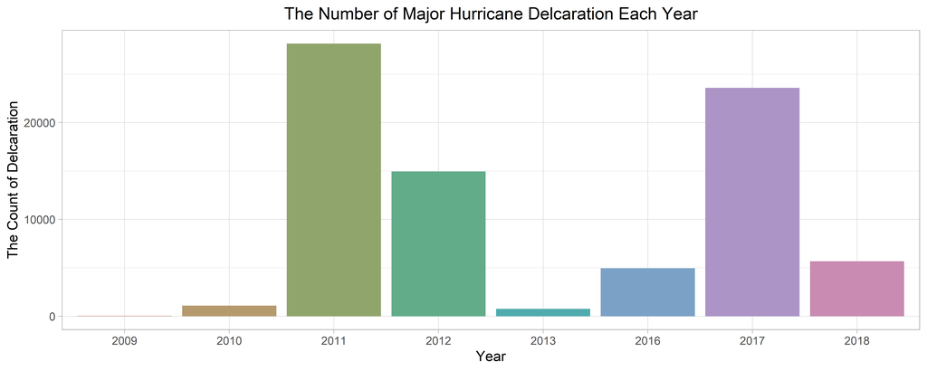

## The Number of States Suffered From Hurricane Each Year

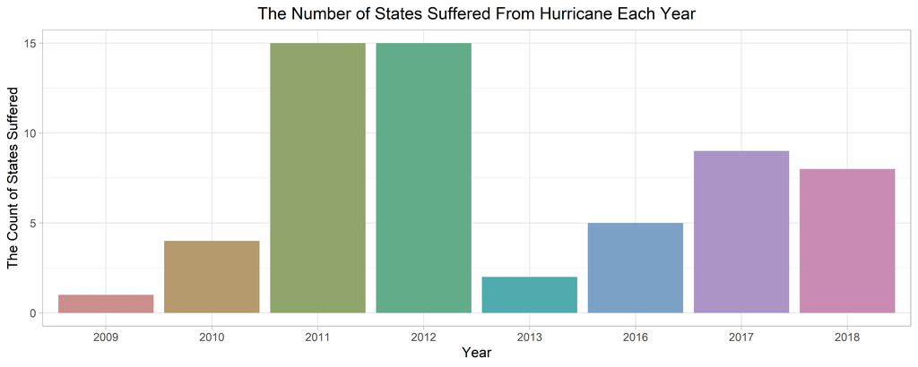

## The Total Project Amount Each Year

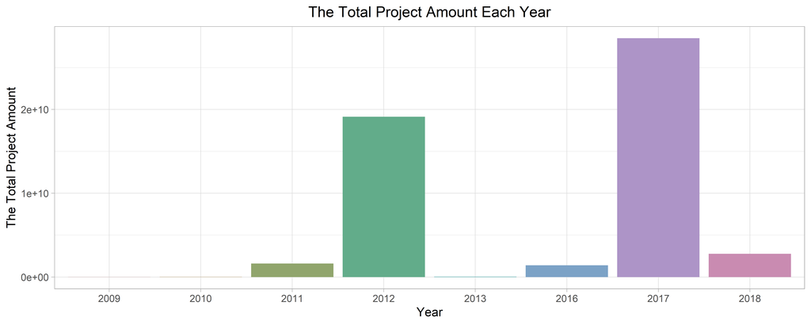

## Severe Years & Peaceful Years

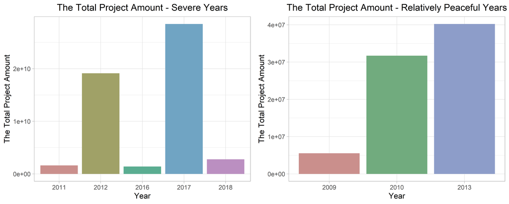

## 2. Spatial Aspect

### The Total Project Amount Each State ALL These Years

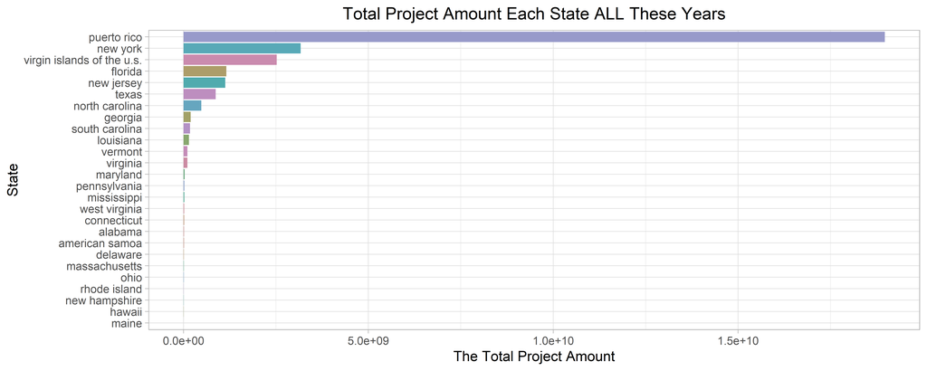

## Top 5 States & Top 5 Counties

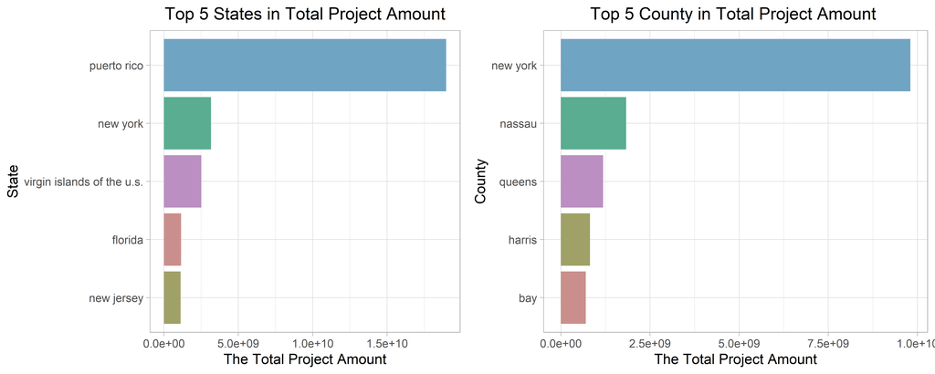

## 3. Hurriance Aspect

### The Total Project Amount of Each Hurricane

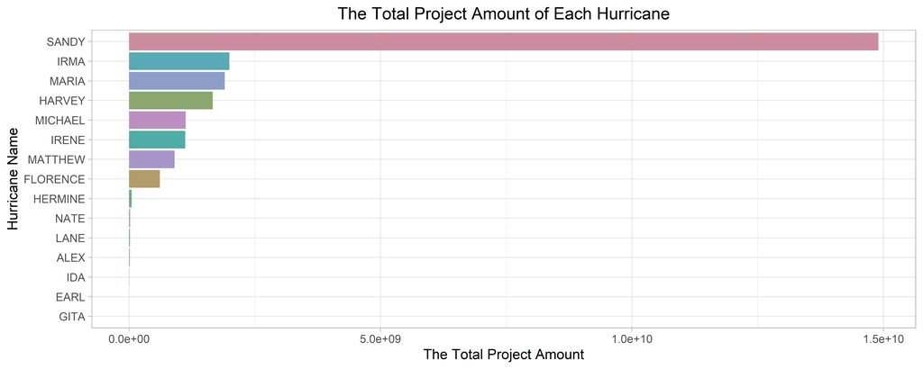

## 4. Project Size Aspect

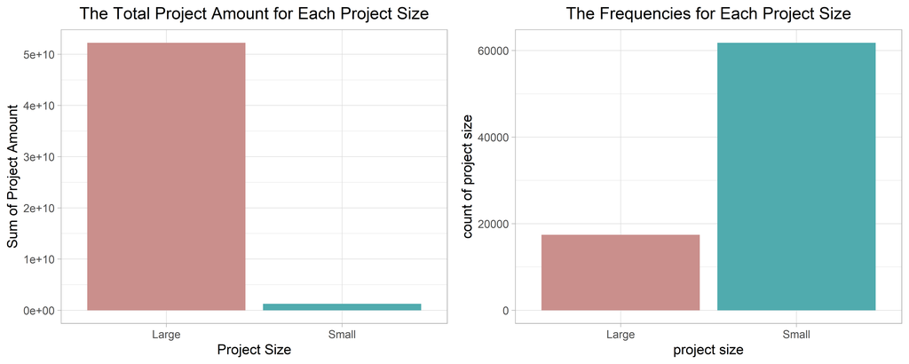

## 5. Damage Category Aspect

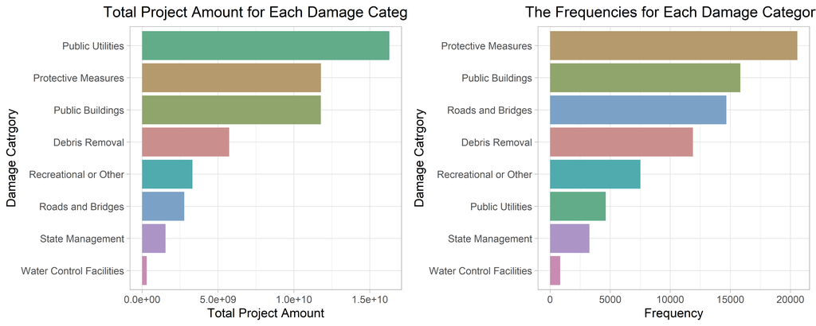

# Mapping The Hurricanes

## Maps of Hurricanes

We draw the total cost of most destructive hurricanes in map.

## Hurricane - SANDY

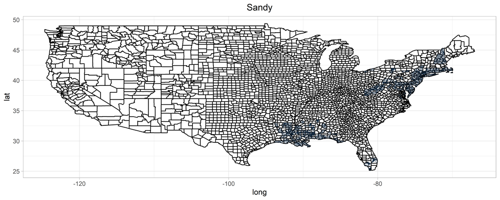

## Hurricane - IRMA

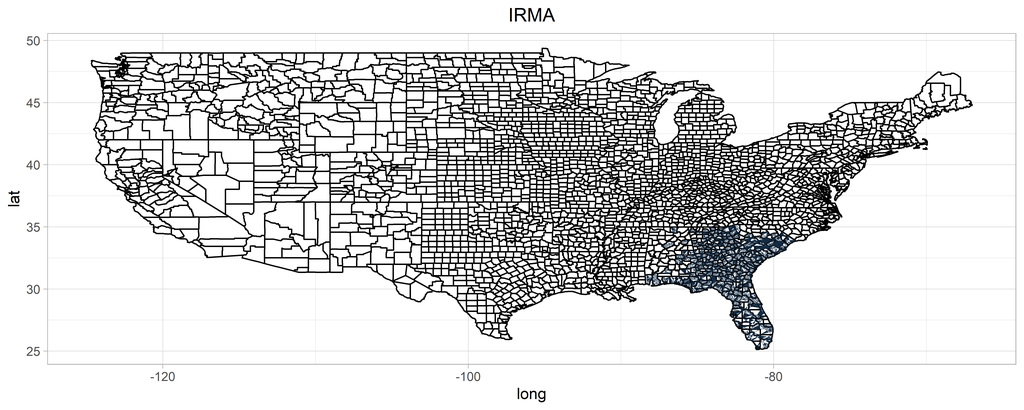

## Hurricane - Harvey

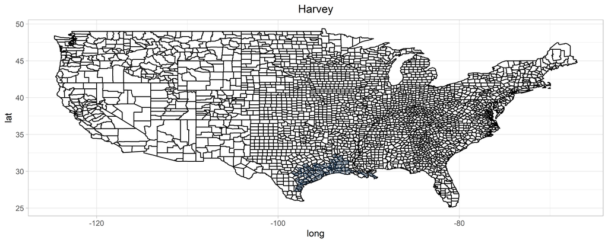

## Hurricane - Michael

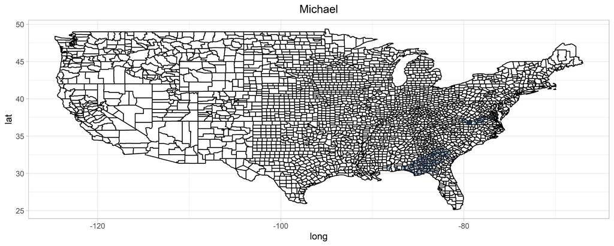

# References

The data is collected from: https://www.fema.gov/openfema-data-page/public-assistance-funded-projects-details-v1

1. Yihui Xie (2020). knitr: A General-Purpose Package for Dynamic Report Generation in R. R package version 1.29. https://github.com/yihui/knitr
2. Hadley Wickham (2019). tidyverse: Easily Install and Load the ‘Tidyverse’. R package version 1.3.0. https://cloud.r-project.org/package=tidyverse
3. Greg Freedman Ellis, Thomas Lumley, Tomasz Żółtak and Ben Schneider (2020). srvyr:‘dplyr’-Like Syntax for Summary Statistics of SUrvey Data. R package version 0.4.0. https://cloud.r-project.org/package=srvyr

# Thanks

Thanks for Listening!